# Project1Markdown

Hongyi Zhu

January 29, 2017

# Text Mining on Presidential Inauguration Speeches

Presidential inauguration often mark a beginning of an era. As a result, the speeches given at inauguration have been carefully preserved and extensively analyzed. It is my intention to analyze this body of documents with text mining techniques available in R, and to identify any interesting patterns that arise. Using the all speeches, I have analyzed word length, word frequency, performed topic modeling, and attempted to identify trends in the word usage by utilizing tools such as term-document matrix, LDA, and the various plot mechanisms in R.

```r
# ======================Loading required libraries======================

library(tm)
library(wordcloud)
library(dplyr)
library(tidytext)
library(cluster)
library(ggplot2)
library(qdap)
library(topicmodels)
library(magrittr)
library(showtext)
```

```r
# ======================Reading in data and setting up corpus======================

# Relative path points to the local folder
folder.path="../data/InauguralSpeeches/"

# get the list of file names
speeches=list.files(path = folder.path, pattern = "*.txt")

# Truncate file names so it is only showing "FirstLast-Term"
prez.out=substr(speeches, 6, nchar(speeches)-4)

# Create a vector NA's equal to the length of the number of speeches
length.speeches=rep(NA, length(speeches))

# Create a corpus
ff.all<-Corpus(DirSource(folder.path))

# load the inauguration list and date
inauguration.list=read.csv("../data/InaugurationInfo.csv")
```

```r
# ======================Clean the data======================

# Use tm_map to strip all white spaces to a single space, to lower case case, remove stop words, empty strings and punctuation.
ff.all<-tm_map(ff.all, stripWhitespace)
ff.all<-tm_map(ff.all, content_transformer(tolower))
ff.all<-tm_map(ff.all, removeWords, stopwords("english"))
ff.all<-tm_map(ff.all, removeWords, c("", "can", "may", "upon", "shall", "will", "must", "never","without", "well", "among", "much", "many", "less", "long", "every", "within", "even", "take", "part", "let", "still", "however", "but"))

# Replace the words that are similar in meaning with one word
ff.all<-tm_map(ff.all, content_transformer(function(x) gsub(x, pattern = "freedom", replacement = "free")))
ff.all<-tm_map(ff.all, content_transformer(function(x) gsub(x, pattern = "american", replacement = "america")))
ff.all<-tm_map(ff.all, content_transformer(function(x) gsub(x, pattern = "national", replacement = "nation")))
ff.all<-tm_map(ff.all, content_transformer(function(x) gsub(x, pattern = "nations", replacement = "nation")))
ff.all<-tm_map(ff.all, content_transformer(function(x) gsub(x, pattern = "states", replacement = "state")))
ff.all<-tm_map(ff.all, content_transformer(function(x) gsub(x, pattern = "good", replacement = "best")))
ff.all<-tm_map(ff.all, content_transformer(function(x) gsub(x, pattern = "rights", replacement = "right")))
# ff.all<-tm_map(ff.all, content_transformer(function(x) gsub(x, pattern = "country", replacement = "nation")))
ff.all<-tm_map(ff.all, content_transformer(function(x) gsub(x, pattern = "citizens", replacement = "citizen")))
ff.all<-tm_map(ff.all, content_transformer(function(x) gsub(x, pattern = "made", replacement = "create")))
ff.all<-tm_map(ff.all, content_transformer(function(x) gsub(x, pattern = "make", replacement = "create")))
ff.all<-tm_map(ff.all, content_transformer(function(x) gsub(x, pattern = "justice", replacement = "just")))
ff.all<-tm_map(ff.all, content_transformer(function(x) gsub(x, pattern = " men ", replacement = "people")))
ff.all<-tm_map(ff.all, content_transformer(function(x) gsub(x, pattern = " americas ", replacement = "america")))
ff.all<-tm_map(ff.all, content_transformer(function(x) gsub(x, pattern = " lives ", replacement = "live")))
ff.all<-tm_map(ff.all, content_transformer(function(x) gsub(x, pattern = " laws ", replacement = "law")))


# Replace dash (-) with space
toSpace<-content_transformer((function(x,pattern) gsub(pattern, " ", x)))
ff.all<-tm_map(ff.all, toSpace, "-|/")
ff.all<-tm_map(ff.all, removePunctuation)
ff.all<-tm_map(ff.all,removeNumbers)

# tdm.all =  a Term Document Matrix
tdm.all<-TermDocumentMatrix(ff.all)
tdm.all=removeSparseTerms(tdm.all,0.99)
dtm.all=DocumentTermMatrix(ff.all)
```

```r
# ======================Convert corpus to data frame======================

# Tokenize the corpus
myCorpusTokenized <- lapply(ff.all, scan_tokenizer)
# concatenate tokens by document, create data frame
myDf <- data.frame(text = sapply(myCorpusTokenized, paste, collapse = " "), stringsAsFactors = FALSE)
myDf <- cbind(inauguration.list,myDf)
myDf[] <- lapply(myDf, as.character)
myDf=myDf[with(myDf, order(Dates)),]
```

# Barplot of the most Frequent Words

I have split the speeches into two intervals chronologically: [1789-1897] and (1897-2017], where 1897 is the inauguration date of William McKinley. Doing so, I hope to examine the most frequent words spoken in each time period. I have a theory that the earlier Presidents are more sensitive and concerned about the Constitution, while the latter Presidents have much more to worry about and thus placed a lesser emphasis on the Consitutiton. After the analysis, it seems to be the case judging from the barplot of the most frequent words: the word “constitution” does not make the cut to be on the most frequent words plot from the latter speeches with the same frequency threshold. A more detailed version of the plots are available in the Output folder.

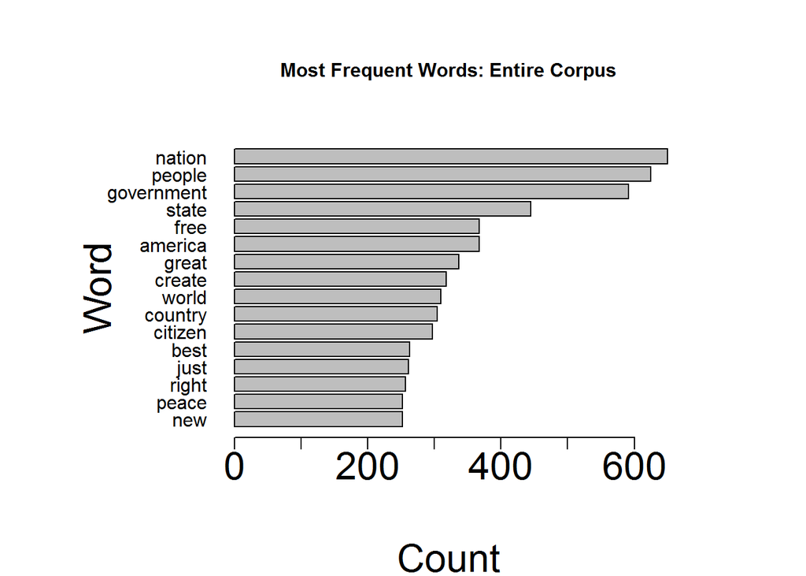

```r
#======================

# Bar Plot for all speeches
termFrequency <- rowSums(as.matrix(tdm.all))
termFrequency <- subset(termFrequency, termFrequency>=250)
termFrequency = sort(termFrequency, decreasing=FALSE)


#png(paste("../output/", "MostCommonWords", ".png", sep=""), width=1500, height=1000)
 par(mar=c(5,9,5,5)+1, mgp=c(5,1,0))
  barplot(termFrequency, horiz=TRUE, las=1, xlab="Count", ylab="Word", main="Most Frequent Words: Entire Corpus", cex.lab=2, cex.main=1, cex.axis=2)
```

```r
#dev.off()
```

It seems that the earlier presidents are more concerned about the newly found union and placed a strong emphasis on the legitamcy of its foundation—by the people, and for the people—and the greatness that it will inherit and achieve in the future. “We shall inherit the earth!!!” kind of tone.

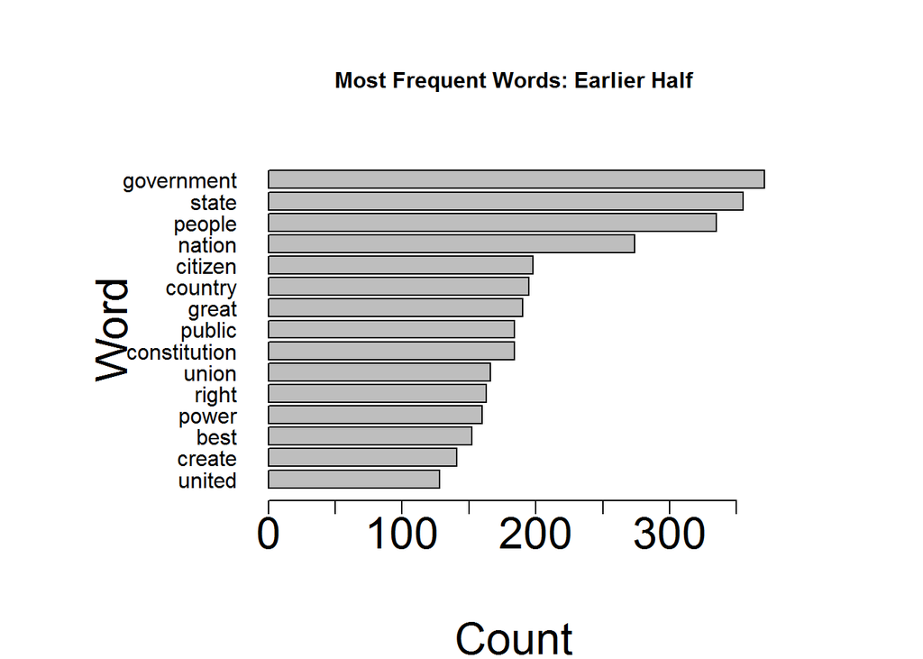

```r
termFrequency <- rowSums(as.matrix(tdm.firstHalf))
termFrequency <- subset(termFrequency, termFrequency>=125)
termFrequency = sort(termFrequency, decreasing=FALSE)

#png(paste("../output/", "MostCommonWords.firstHalf", ".png", sep=""), width=1500, height=1000)
 par(mar=c(5,9,5,5)+1, mgp=c(5,1,0))
  barplot(termFrequency, horiz=TRUE, las=1, xlab="Count", ylab="Word", main="Most Frequent Words: Earlier Half", cex.lab=2, cex.main=1, cex.axis=2)
```

```r
#dev.off()
```

After a century or so, Presidents seem to be concerned about the role the United States plays in the world. There were a couple of major “wars”" in the last century that the presidents explicitly mentioned in their inaugurations: WWI, WWII, Korean War, Vietnam War. As a result, achieving “peace”" became a priority on the agenda of the Presidents, and that “Constitution” took a back seat by not making to this list—nor is it on the more detailed list with frequency threshold of >75.

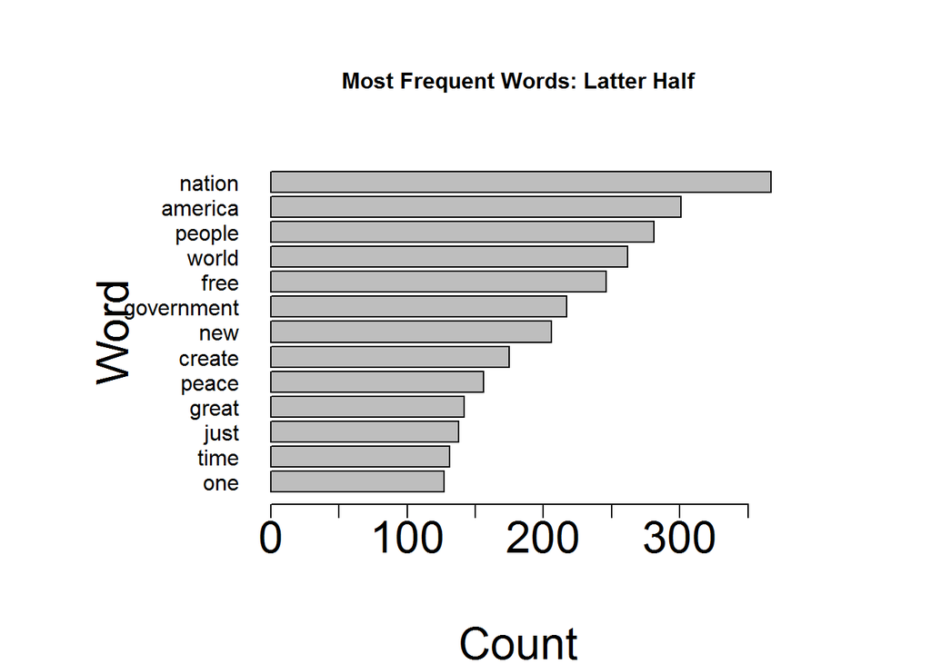

```r
termFrequency <- rowSums(as.matrix(tdm.secondHalf))
termFrequency <- subset(termFrequency, termFrequency>=125)
termFrequency = sort(termFrequency, decreasing=FALSE)

#png(paste("../output/", "MostCommonWords.secondtHalf", ".png", sep=""), width=1500, height=1000)
  par(mar=c(5,9,5,5)+1, mgp=c(5,1,0))
  barplot(termFrequency, horiz=TRUE, las=1, xlab="Count", ylab="Word", main="Most Frequent Words: Latter Half",    cex.lab=2, cex.main=1, cex.axis=2)
```

```r
#dev.off()
```

# Word Length

I have a hypothesis (stolen from my English class that bashes modern writers and pop cultures) that there is a downward trend in word length as exemplified by our texting abbreviations and sound bites on Television.

```r
# Overall
words <- dtm.all %>% colnames%>% (function(x) x[nchar(x)<20])
dist_tab(nchar(words))
```

```
##    interval freq cum.freq percent cum.percent
## 1         3  127      127    1.38        1.38
## 2         4  545      672    5.92        7.30
## 3         5  836     1508    9.08       16.39
## 4         6 1211     2719   13.16       29.55
## 5         7 1430     4149   15.54       45.09
## 6         8 1348     5497   14.65       59.74
## 7         9 1208     6705   13.13       72.86
## 8        10  987     7692   10.73       83.59
## 9        11  674     8366    7.32       90.92
## 10       12  401     8767    4.36       95.27
## 11       13  200     8967    2.17       97.45
## 12       14  116     9083    1.26       98.71
## 13       15   47     9130    0.51       99.22
## 14       16   29     9159    0.32       99.53
## 15       17   22     9181    0.24       99.77
## 16       18   13     9194    0.14       99.91
## 17       19    8     9202    0.09      100.00
```

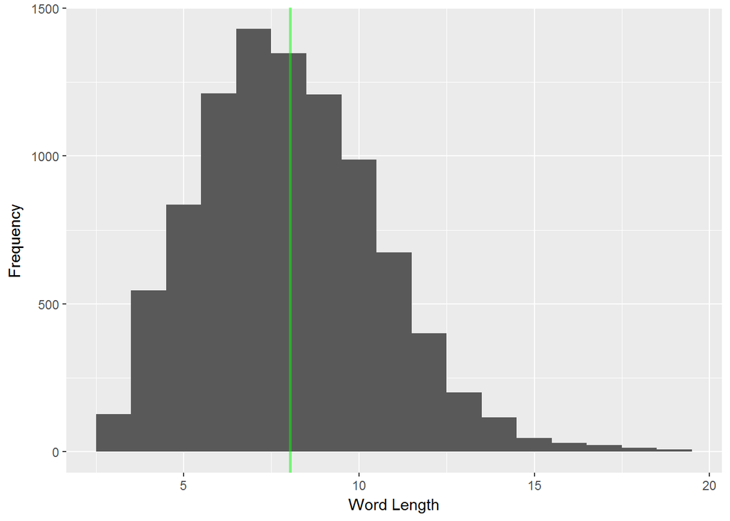

```r
data.frame(nletters=nchar(words)) %>%
  ggplot(aes(x=nletters)) +
  geom_histogram(binwidth = 1) +
  geom_vline(xintercept=mean(nchar(words)),
             colour="green", size=1, alpha=0.5) +
  labs(x="Word Length", y="Frequency")
```

After the analysis, I have calculated the distribution of length of words in these inauguration speeches. Sample size, their mean, and standard deviation for word length of the earlier and latter speeches are: **6270** words with a mean of **8.060606** and standard deviation of **2.516716** and **6220** words with a mean of **7.694534** and a standard deviation of **2.521227** respectively. Assuming equal variance (a somewhat plausible assumption), a simple t-test: yields a p-value of 5.069e-16. In other words, **I was able to reject the hypothesis that the word lengths stayed the same**, and conclude that the words have became shorter since the 1897 McKinley inauguration.

```r
# First Half
words <- dtm.firstHalf %>% colnames%>% (function(x) x[nchar(x)<20])
dist_tab(nchar(words))
```

```
##    interval freq cum.freq percent cum.percent
## 1         3   81       81    1.29        1.29
## 2         4  362      443    5.77        7.07
## 3         5  536      979    8.55       15.61
## 4         6  834     1813   13.30       28.92
## 5         7  940     2753   14.99       43.91
## 6         8  939     3692   14.98       58.88
## 7         9  838     4530   13.37       72.25
## 8        10  712     5242   11.36       83.60
## 9        11  468     5710    7.46       91.07
## 10       12  293     6003    4.67       95.74
## 11       13  130     6133    2.07       97.81
## 12       14   70     6203    1.12       98.93
## 13       15   29     6232    0.46       99.39
## 14       16   15     6247    0.24       99.63
## 15       17   14     6261    0.22       99.86
## 16       18    7     6268    0.11       99.97
## 17       19    2     6270    0.03      100.00
```

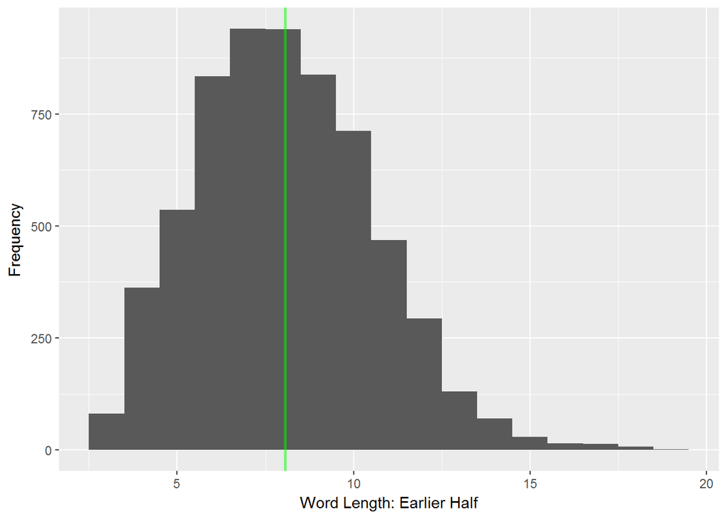

```r
data.frame(nletters=nchar(words)) %>%
  ggplot(aes(x=nletters)) +
  geom_histogram(binwidth = 1) +
  geom_vline(xintercept=mean(nchar(words)),
             colour="green", size=1, alpha=0.5) +
  labs(x="Word Length: Earlier Half", y="Frequency")
```

```r
  firstHalf.count=nchar(words)

  # Second Half
words <- dtm.secondHalf %>% colnames%>% (function(x) x[nchar(x)<20])
dist_tab(nchar(words))
```

```
##    interval freq cum.freq percent cum.percent
## 1         3  110      110    1.77        1.77
## 2         4  458      568    7.36        9.13
## 3         5  683     1251   10.98       20.11
## 4         6  900     2151   14.47       34.58
## 5         7 1010     3161   16.24       50.82
## 6         8  904     4065   14.53       65.35
## 7         9  753     4818   12.11       77.46
## 8        10  569     5387    9.15       86.61
## 9        11  386     5773    6.21       92.81
## 10       12  208     5981    3.34       96.16
## 11       13  112     6093    1.80       97.96
## 12       14   66     6159    1.06       99.02
## 13       15   23     6182    0.37       99.39
## 14       16   17     6199    0.27       99.66
## 15       17    9     6208    0.14       99.81
## 16       18    6     6214    0.10       99.90
## 17       19    6     6220    0.10      100.00
```

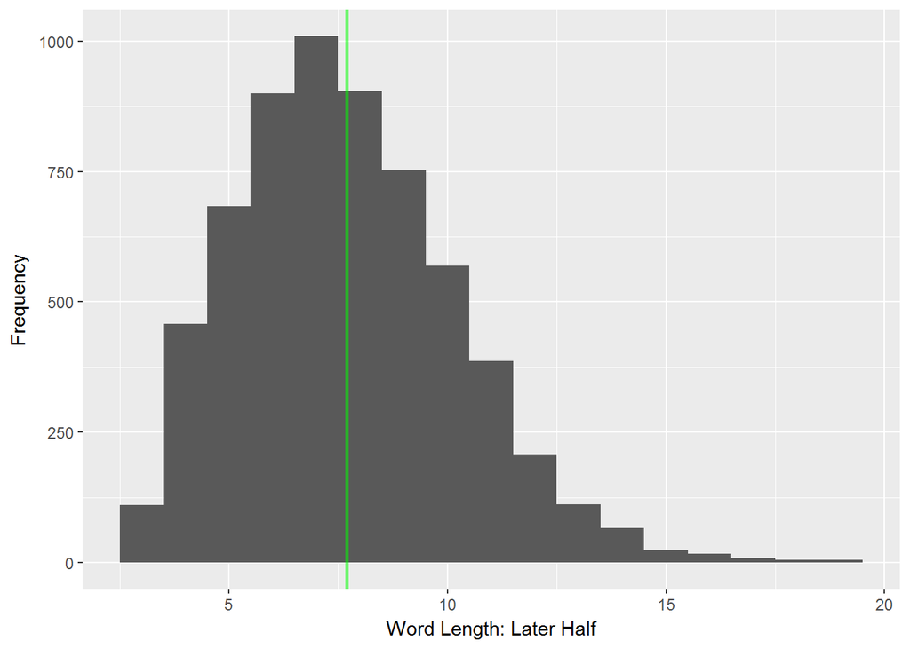

```r
data.frame(nletters=nchar(words)) %>%
  ggplot(aes(x=nletters)) +
  geom_histogram(binwidth = 1) +
  geom_vline(xintercept=mean(nchar(words)),
             colour="green", size=1, alpha=0.5) +
  labs(x="Word Length: Later Half", y="Frequency")
```

```r
  secondHalf.count=nchar(words)
```

Here is the result from the two sample t-test assuming equal variance of the hypothesis that the word length stayed constant from the earlier half to the later half.

```r
  t.test(firstHalf.count, secondHalf.count, var.equal = TRUE, paired=FALSE)
```

```
##
##  Two Sample t-test
##
## data:  firstHalf.count and secondHalf.count
## t = 8.1207, df = 12488, p-value = 5.069e-16
## alternative hypothesis: true difference in means is not equal to 0
## 95 percent confidence interval:
##  0.2777105 0.4544341
## sample estimates:
## mean of x mean of y
##  8.060606  7.694534
```

On the other hand, the Democrat vs. Republican split offers much less insight and is only included to make that point.

```r
# Democrat
words <- dtm.democ %>% colnames%>% (function(x) x[nchar(x)<20])
dist_tab(nchar(words))
```

```
##    interval freq cum.freq percent cum.percent
## 1         3   92       92    1.69        1.69
## 2         4  389      481    7.14        8.83
## 3         5  573     1054   10.52       19.35
## 4         6  758     1812   13.92       33.27
## 5         7  889     2701   16.32       49.60
## 6         8  791     3492   14.52       64.12
## 7         9  679     4171   12.47       76.59
## 8        10  540     4711    9.92       86.50
## 9        11  328     5039    6.02       92.53
## 10       12  210     5249    3.86       96.38
## 11       13   93     5342    1.71       98.09
## 12       14   55     5397    1.01       99.10
## 13       15   17     5414    0.31       99.41
## 14       16   15     5429    0.28       99.69
## 15       17    7     5436    0.13       99.82
## 16       18    6     5442    0.11       99.93
## 17       19    4     5446    0.07      100.00
```

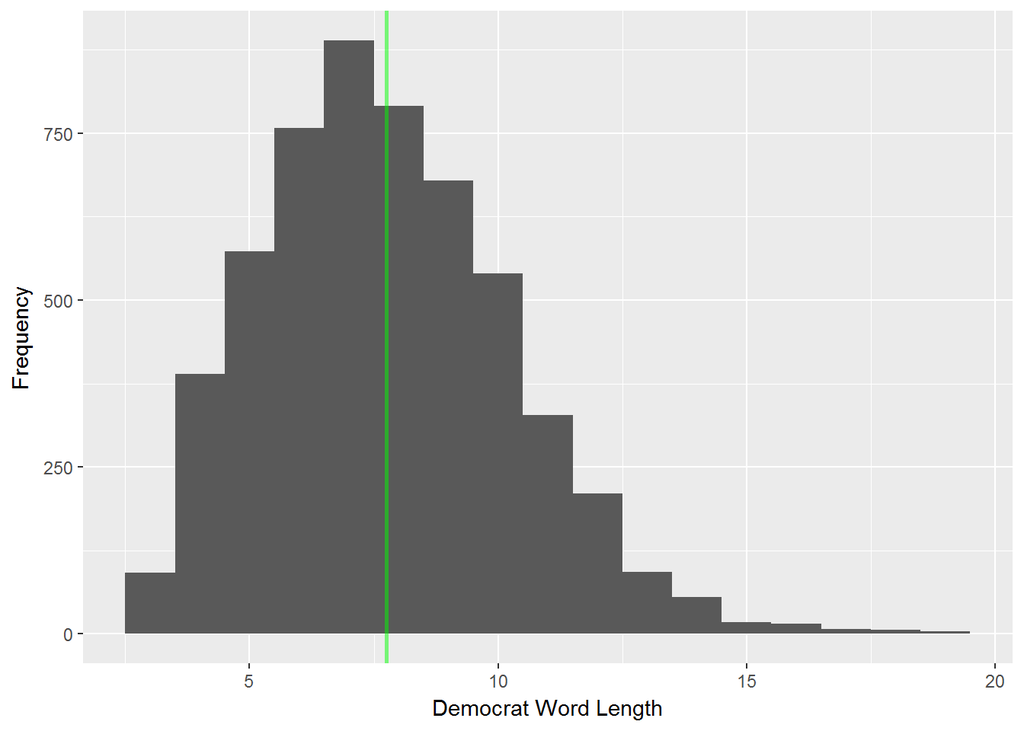

```r
data.frame(nletters=nchar(words)) %>%
  ggplot(aes(x=nletters)) +
  geom_histogram(binwidth = 1) +
  geom_vline(xintercept=mean(nchar(words)),
             colour="green", size=1, alpha=0.5) +
  labs(x="Democrat Word Length", y="Frequency")
```

```r
# Republican
words <- dtm.repub %>% colnames%>% (function(x) x[nchar(x)<20])
dist_tab(nchar(words))
```

```
##    interval freq cum.freq percent cum.percent
## 1         3   99       99    1.60        1.60
## 2         4  432      531    7.00        8.60
## 3         5  645     1176   10.45       19.05
## 4         6  876     2052   14.19       33.24
## 5         7  997     3049   16.15       49.39
## 6         8  881     3930   14.27       63.66
## 7         9  777     4707   12.59       76.25
## 8        10  594     5301    9.62       85.87
## 9        11  409     5710    6.63       92.50
## 10       12  224     5934    3.63       96.13
## 11       13  117     6051    1.90       98.02
## 12       14   63     6114    1.02       99.04
## 13       15   28     6142    0.45       99.50
## 14       16   15     6157    0.24       99.74
## 15       17    9     6166    0.15       99.89
## 16       18    4     6170    0.06       99.95
## 17       19    3     6173    0.05      100.00
```

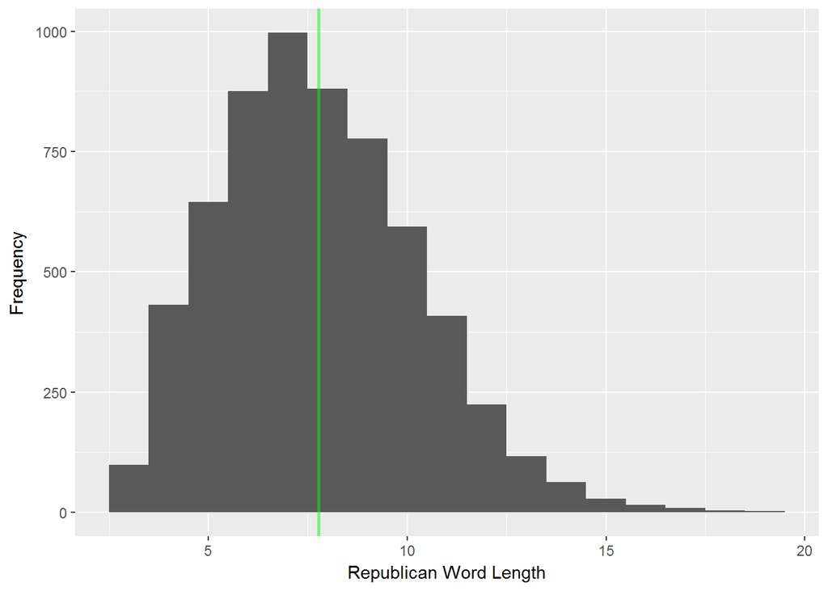

```r
data.frame(nletters=nchar(words)) %>%
  ggplot(aes(x=nletters)) +
  geom_histogram(binwidth = 1) +
  geom_vline(xintercept=mean(nchar(words)),
             colour="green", size=1, alpha=0.5) +
  labs(x="Republican Word Length", y="Frequency")
```

# Frequency Analysis

```r
print("This is the 30 most frequent words and their frequency in the entire corpus")
```

```
## [1] "This is the 30 most frequent words and their frequency in the entire corpus"
```

```r
dtm.all=DocumentTermMatrix(ff.all)
freq.all=colSums(as.matrix(dtm.all))
ord.all<-order(freq.all)
# 10 most frequent terms and their count
freq.all[tail(ord.all, 30)]
```

```
##         life       spirit        years       fellow          war
##          136          138          141          145          176
##          law        union       united constitution         time
##          188          188          203          208          216
##          now       public        power          one          new
##          225          225          236          249          252
##        peace        right         just         best      citizen
##          252          257          261          263          297
##      country        world       create        great      america
##          304          310          318          337          367
##         free        state   government       people       nation
##          367          445          591          625          650
```

```r
print("This is the 30 most frequent words and their frequency in the first half")
```

```
## [1] "This is the 30 most frequent words and their frequency in the first half"
```

```r
freq.firstHalf=colSums(as.matrix(dtm.firstHalf))
ord.firstHalf<-order(freq.firstHalf)
freq.firstHalf[tail(ord.firstHalf,30)]
```

```
##       spirit         duty       powers     congress         time
##           74           81           82           84           85
##      foreign       fellow        peace    interests          war
##           86           92           93           95          103
##          law          now         free         just          one
##          108          110          119          120          121
##       united       create         best        power        right
##          128          141          152          160          163
##        union constitution       public        great      country
##          166          184          184          190          195
##      citizen       nation       people        state   government
##          198          274          335          355          371
```

```r
print("This is the 30 most frequent words and their frequency in the second half")
```

```
## [1] "This is the 30 most frequent words and their frequency in the second half"
```

```r
freq.secondHalf=colSums(as.matrix(dtm.secondHalf))
ord.secondHalf<-order(freq.secondHalf)
freq.secondHalf[tail(ord.secondHalf,30)]
```

```
##        god      power        war     united      years        law
##         71         72         73         75         76         80
##       hope       know      today      state      right    citizen
##         82         88         89         90         92         98
##       work       life       best    country        now        one
##         99        100        107        109        113        127
##       time       just      great      peace     create        new
##        131        138        142        156        175        206
## government       free      world     people    america     nation
##        217        246        262        281        301        367
```

```r
# get distribution of frequencies
head(table(freq.all),15)
```

```
## freq.all
##    1    2    3    4    5    6    7    8    9   10   11   12   13   14   15
## 3992 1387  756  538  345  301  216  182  157  134  118   90   86   80   41
```

```r
tail(table(freq.all),15)
```

```
## freq.all
## 249 252 257 261 263 297 304 310 318 337 367 445 591 625 650
##   1   2   1   1   1   1   1   1   1   1   2   1   1   1   1
```

# association analysis

```r
findAssocs(dtm.all,c("constitution"), corlimit = 0.7)
```

```
## $constitution
##      prescribed        disunion misconstruction           state
##            0.81            0.80            0.79            0.79
##            void     alternative       ascertain     confederacy
##            0.79            0.78            0.78            0.78
##         contain         deprive     exclusively            mode
##            0.78            0.78            0.78            0.78
##           oaths       published        uncreate       despotism
##            0.78            0.78            0.78            0.77
##     departments       exercised        majority      respective
##            0.75            0.75            0.75            0.75
##            case      difficulty        although         derives
##            0.74            0.74            0.73            0.73
##         existed           power        actually          appear
##            0.73            0.73            0.72            0.72
##       exclusive           grant      introduced        conceive
##            0.72            0.72            0.72            0.71
##       extensive      magistrate        negative         similar
##            0.71            0.71            0.71            0.71
##        adoption         attempt        contrary
##            0.70            0.70            0.70
```

```r
findAssocs(dtm.firstHalf,c("constitution"), corlimit = 0.7)
```

```
## $constitution
##         compose misconstruction      prescribed            void
##            0.82            0.82            0.82            0.82
##          acting        disunion        majority          simple
##            0.81            0.81            0.81            0.81
##     alternative       ascertain         contain         deprive
##            0.80            0.80            0.80            0.80
##           oaths       published          really             say
##            0.80            0.80            0.80            0.80
##       vigilance        mischief       perfectly           ruler
##            0.80            0.78            0.78            0.78
##        uncreate         central         justify         liberty
##            0.78            0.77            0.77            0.77
##          master            mode             one            acts
##            0.77            0.77            0.77            0.76
##     confederacy       despotism     exclusively           hands
##            0.76            0.76            0.76            0.76
##        although      difficulty      instrument       interfere
##            0.75            0.75            0.75            0.75
##           state            used        adoption     departments
##            0.75            0.75            0.74            0.74
##       exercised           given       intention            mine
##            0.74            0.74            0.74            0.74
##           power      amendments          anyone          appear
##            0.74            0.73            0.73            0.73
##           apply            case        conceive        contrary
##            0.73            0.73            0.73            0.73
##      convention         derives       different       executive
##            0.73            0.73            0.73            0.73
##           grant        hitherto        intended      introduced
##            0.73            0.73            0.73            0.73
##         similar        actually         attempt          become
##            0.73            0.72            0.72            0.72
##      celebrated           claim       exclusive         existed
##            0.72            0.72            0.72            0.72
##         granted           hasty        negative      respective
##            0.72            0.72            0.72            0.72
##           right         another           chief       extensive
##            0.72            0.71            0.71            0.71
##          matter      operations         perfect         citizen
##            0.71            0.71            0.71            0.70
```

```r
findAssocs(dtm.secondHalf,c("constitution"), corlimit = 0.7)
```

```
## $constitution
##       fully legislative   direction   following     pursued       reign
##        0.87        0.84        0.83        0.82        0.82        0.82
##    property     support   discharge     verdict   reduction      result
##        0.81        0.78        0.77        0.77        0.76        0.76
##     results      method    provided       found   relations   carefully
##        0.76        0.75        0.75        0.74        0.74        0.73
##  consequent  cultivated   disregard    doctrine    election   favorable
##        0.73        0.73        0.73        0.73        0.73        0.73
##  identified       merit   observing     phrases      potent     returns
##        0.73        0.73        0.73        0.73        0.73        0.73
##      seldom   undoubted voluntarily fundamental   movements   permanent
##        0.73        0.73        0.73        0.72        0.72        0.72
##    revenues    tribunal    advanced  employment      reason      relief
##        0.72        0.72        0.71        0.71        0.71        0.71
##      remedy        save    constant
##        0.71        0.71        0.70
```

# Clustering

I have removed sparse terms so that the sparsity for the overall, earlier half, latter half are 0.25, 0.15, and 0.15 respectively. Clustering is a technique for the machine to classify and group objects that are of similar nature. These clusters show the words that often appear together or make sense when used together. For example, “hope” and “future” goes together to promote the optimistic view of the future, “world” and “peace” go together as the Presidents would like to achieve peace worldwide. Lastly, “just” and “best” are together because the Presidents would like people to believe that their policy is fair, and therefore just, and is best. The more detailed (made from less sparse matrices) cluster diagram are available in the output folder.

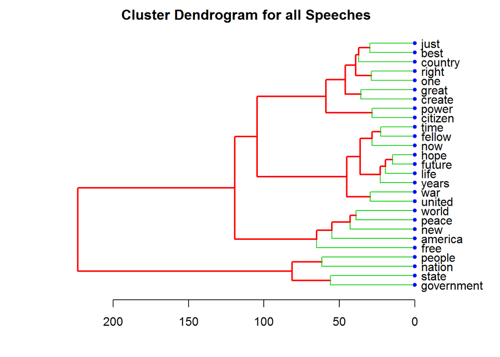

```r
# all
dtms <- removeSparseTerms(dtm.all,0.25)
d=dist(t(dtms), method="euclidian")
fit<-hclust(d=d,method="ward.D")

#png(paste("../output/", "Cluster Dendrogram", ".png", sep=""), width=1500, height=1000)
  nodePar <- list(lab.cex = 1, pch = c(NA, 19), cex = 0.7, col = "blue")
  par(mar=c(4,4.5,2,5))
  plot(as.dendrogram(fit),hang=-1, main="Cluster Dendrogram for all Speeches", horiz=TRUE,nodePar = nodePar, edgePar = list(col = 2:3, lwd = 2:1))
```

```r
  group<-cutree(fit, k=4)
#dev.off()
```

In the earlier half of the speeches, the cluster indicates that the Presidents are often preoccupied with the basic building blocks of a nation: “power”, “constitution”, “citizen”, “duties”, and “people”. It seems that the Presidents are trying to steer the country to the right direction, and the future is less certain judging from the tone of the speeches.

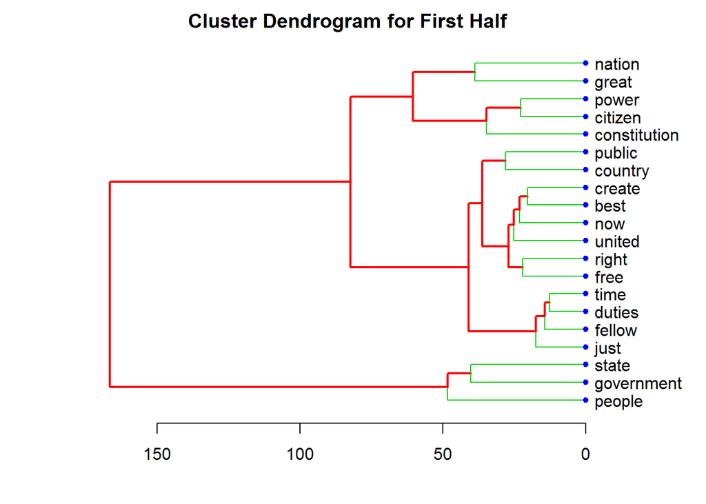

```r
# first half
dtms.firstHalf=removeSparseTerms(dtm.firstHalf,0.15)
d=dist(t(dtms.firstHalf), method="euclidian")
fit.firstHalf<-hclust(d=d,method="ward.D")

#png(paste("../output/", "Cluster Dendrogram for First Half", ".png", sep=""), width=1500, height=1000)
  par(mar=c(4,4.5,2,5))
  nodePar <- list(lab.cex = 1, pch = c(NA, 19), cex = 0.7, col = "blue")
  plot(as.dendrogram(fit.firstHalf),hang=-1, main="Cluster Dendrogram for First Half", horiz=TRUE,nodePar = nodePar, edgePar = list(col = 2:3, lwd = 2:1))
```

```r
  group<-cutree(fit.firstHalf, k=6)
#dev.off()
```

In the later half, with words such as “work”, “life”, “hope”, “future”, “time”, it seems that the Presidents are trying to appeal to our everyday life and set up the image that life is good in America now and will continue to be this way into the future–future is more certain in this case, as long as people continue to behave.

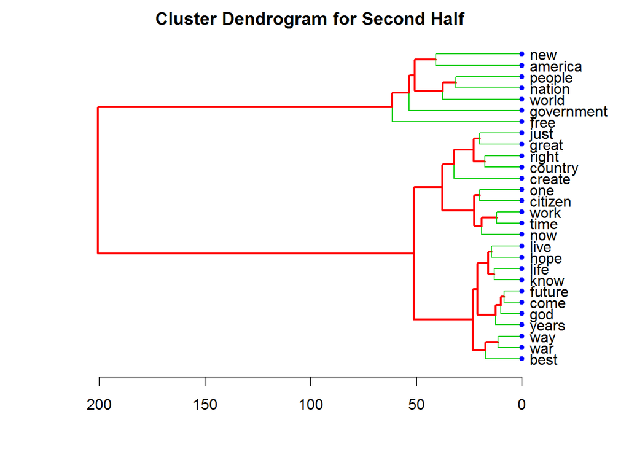

```r
# second half
dtms.secondHalf=removeSparseTerms(dtm.secondHalf,0.15)
d=dist(t(dtms.secondHalf), method="euclidian")
fit.secondHalf<-hclust(d=d,method="ward.D")

#png(paste("../output/", "Cluster Dendrogram for Second Half", ".png", sep=""), width=1500, height=1000)
    par(mar=c(4,4.5,2,5))
    nodePar <- list(lab.cex = 1, pch = c(NA, 19), cex = 0.7, col = "blue")
    plot(as.dendrogram(fit.secondHalf),hang=-1, main="Cluster Dendrogram for Second Half", horiz=TRUE,nodePar = nodePar, edgePar = list(col = 2:3, lwd = 2:1))
```

```r
  group<-cutree(fit.secondHalf, k=6)
#dev.off()
```

# Topic Modeling

Topic model is a type of statistical model for discovering abstract “topics” in a set of documents. Below are the topics often discussed by the Democratic Presidents.

```r
burnin = 4000
iter=2000
thin=500
seed=list(1,1,1,1,1)
nstart=5
best=TRUE

k=15

ldaOut.democ=LDA(dtm.democ,k,method="Gibbs", control=list(nstart=nstart, seed=seed, best=best, burnin=burnin, iter=iter, thin=thin))

# Write results to csv
ldaOutdemoc.topics=as.matrix(topics(ldaOut.democ))
table(c(1:k, ldaOutdemoc.topics))
```

```
##
##  1  2  3  4  5  6  7  8  9 10 11 12 13 14 15
##  1  2  1 12  1  2  1  1  8  2  2  2  1  1  1
```

```r
write.csv(ldaOutdemoc.topics, file=paste( "DocstoTopics.csv"))

#top 20 terms in each topic
ldaOutdemoc.terms <- as.matrix(terms(ldaOut.democ,20))
write.csv(ldaOutdemoc.terms,file=paste("TopicsToTerms.csv"))

#probabilities associated with each topic assignment
topicProbabilities <- as.data.frame(ldaOut.democ@gamma)
write.csv(topicProbabilities,file=paste("TopicProbabilities.csv"))

# Print out the topics
termsdemoc.beta=ldaOut.democ@beta
termsdemoc.beta=scale(termsdemoc.beta)
topicsdemoc.terms=NULL
for(i in 1:k)
{
  topicsdemoc.terms=rbind(topicsdemoc.terms, ldaOut.democ@terms[order(termsdemoc.beta[i,], decreasing = TRUE)[1:7]])
}
topicsdemoc.terms
```

```
##       [,1]        [,2]          [,3]             [,4]
##  [1,] "enduring"  "becoming"    "presidential"   "supreme"
##  [2,] "fallen"    "process"     "processes"      "thoughts"
##  [3,] "weakness"  "begin"       "west"           "complete"
##  [4,] "new"       "democracy"   "change"         "way"
##  [5,] "revenue"   "increasing"  "sections"       "manufactures"
##  [6,] "needs"     "favor"       "extravagance"   "governmental"
##  [7,] "neither"   "perfect"     "reach"          "except"
##  [8,] "encourage" "ambitions"   "flow"           "aids"
##  [9,] "subject"   "territory"   "administration" "blessings"
## [10,] "dark"      "discipline"  "emergency"      "respects"
## [11,] "economic"  "recovery"    "program"        "growing"
## [12,] "journey"   "jobs"        "middle"         "safe"
## [13,] "judge"     "contains"    "convictions"    "efficiency"
## [14,] "expect"    "forbearance" "indeed"         "advancement"
```

[output cut: 17 more lines]

```r
ldaOutdemoc.terms
```

```
##       Topic 1        Topic 2      Topic 3      Topic 4     Topic 5
##  [1,] "enduring"     "purpose"    "pledge"     "nation"    "union"
##  [2,] "man"          "action"     "powerful"   "people"    "one"
##  [3,] "given"        "things"     "little"     "new"       "revenue"
##  [4,] "hour"         "task"       "arms"       "world"     "happy"
##  [5,] "war"          "duty"       "complete"   "create"    "congress"
##  [6,] "becoming"     "means"      "sides"      "now"       "interests"
##  [7,] "covenant"     "great"      "weakness"   "time"      "system"
##  [8,] "learned"      "see"        "personal"   "free"      "duties"
##  [9,] "road"         "look"       "whose"      "just"      "increasing"
## [10,] "always"       "use"        "begin"      "life"      "preserved"
## [11,] "civilization" "essential"  "join"       "america"   "sections"
## [12,] "defense"      "order"      "west"       "one"       "texas"
## [13,] "increase"     "thought"    "bear"       "work"      "protected"
## [14,] "instead"      "democratic" "globe"      "great"     "another"
```

[output cut: 69 more lines]

Topics from Republican Presidents:

```r
burnin = 4000
iter=2000
thin=500
seed=list(1,1,1,1,1)
nstart=5
best=TRUE

k=15

ldaOut.repub=LDA(dtm.repub,k,method="Gibbs", control=list(nstart=nstart, seed=seed, best=best, burnin=burnin, iter=iter, thin=thin))

# Write results to csv
ldaOutrepub.topics=as.matrix(topics(ldaOut.repub))
table(c(1:k, ldaOutrepub.topics))
```

```
##
##  1  2  3  4  5  6  7  8  9 10 11 12 13 14 15
##  2  2  1  8  1  3  1  2  2 11  2  1  2  1  1
```

```r
write.csv(ldaOutrepub.topics, file=paste( "DocstoTopicsRepub.csv"))

#top 20 terms in each topic
ldaOutrepub.terms <- as.matrix(terms(ldaOut.repub,20))
write.csv(ldaOutdemoc.terms,file=paste("TopicsToTermsRepub.csv"))

#probabilities associated with each topic assignment
topicProbabilities <- as.data.frame(ldaOut.repub@gamma)
write.csv(topicProbabilities,file=paste("TopicProbabilitiesRepub.csv"))

# Print out the topics
termsrepub.beta=ldaOut.repub@beta
termsrepub.beta=scale(termsrepub.beta)
topicsrepub.terms=NULL
for(i in 1:k)
{
  topicsrepub.terms=rbind(topicsrepub.terms, ldaOut.repub@terms[order(termsrepub.beta[i,], decreasing = TRUE)[1:7]])
}
topicsrepub.terms
```

```
##       [,1]           [,2]            [,3]          [,4]
##  [1,] "expressed"    "indispensable" "pray"        "seemed"
##  [2,] "union"        "slave"         "surrendered" "cases"
##  [3,] "weapons"      "answer"        "heroes"      "greatness"
##  [4,] "duties"       "found"         "condition"   "protection"
##  [5,] "ballot"       "necessities"   "ordinary"    "cotton"
##  [6,] "everyone"     "families"      "yes"         "anyone"
##  [7,] "hearts"       "sometimes"     "putting"     "breeze"
##  [8,] "south"        "interstate"    "army"        "canal"
##  [9,] "stands"       "definite"      "whenever"    "reaching"
## [10,] "know"         "faith"         "home"        "things"
## [11,] "organization" "advancement"   "contributed" "profound"
## [12,] "though"       "goal"          "centuries"   "decent"
## [13,] "relationship" "righteousness" "nationity"   "normal"
## [14,] "treasury"     "thousands"     "neglect"     "arrangements"
```

[output cut: 17 more lines]

```r
ldaOutrepub.terms
```

```
##       Topic 1         Topic 2          Topic 3       Topic 4
##  [1,] "war"           "union"          "believe"     "government"
##  [2,] "rather"        "constitution"   "economy"     "state"
##  [3,] "neither"       "now"            "reduce"      "people"
##  [4,] "care"          "constitutional" "voices"      "law"
##  [5,] "cause"         "one"            "look"        "country"
##  [6,] "efforts"       "time"           "weapons"     "nation"
##  [7,] "industries"    "slavery"        "answer"      "create"
##  [8,] "expressed"     "case"           "compassion"  "public"
##  [9,] "receive"       "equal"          "greatest"    "congress"
## [10,] "certain"       "merely"         "greatness"   "great"
## [11,] "continent"     "provision"      "heroes"      "best"
## [12,] "indispensable" "section"        "open"        "right"
## [13,] "navy"          "always"         "two"         "now"
## [14,] "past"          "change"         "fair"        "citizen"
```

[output cut: 69 more lines]

# Frequency of certain words

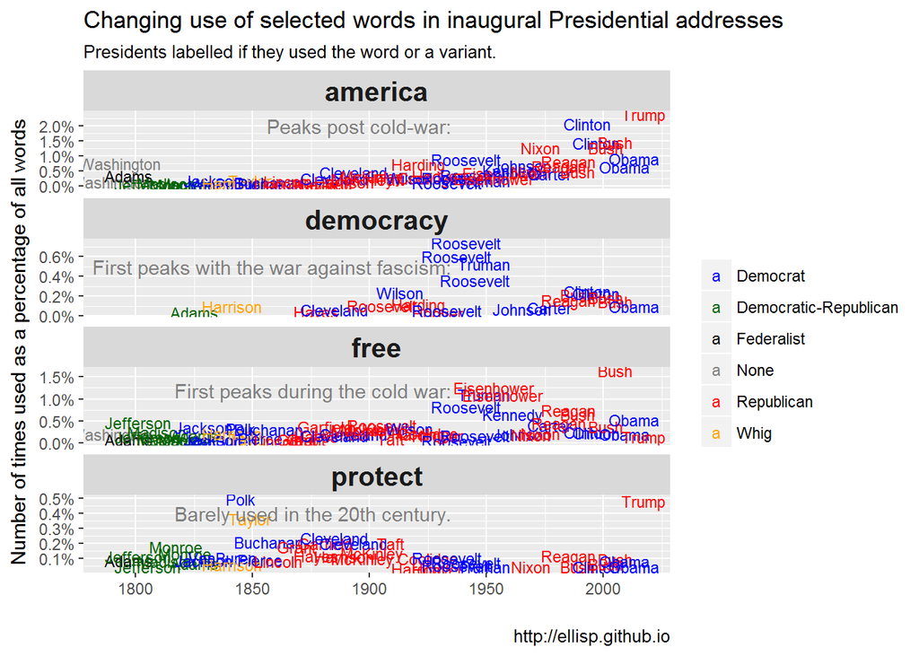

```r
library(quanteda)
library(tidytext)
library(tidyverse)
library(scales)
library(stringr)
library(wordcloud)
library(viridis)
library(grid)
library(testthat)

#==============data downloads and prep========================
# Create a named vector of colours for representing the different parties, using
# later in both ggplot and base graphics (wordcloud).
# The Democratic-Republican party colours were red, white and blue but I need something distinctive.
parties <- c(None = "grey50", Federalist = "black", `Democratic-Republican` = "darkgreen",
             Whig = "orange", Republican = "red", Democrat = "blue")


# Get the Trump speech
# originally copied this from http://abcnews.go.com/Politics/full-text-president-donald-trumps-inauguration-speech/story?id=44915821
trump <- paste(readLines("https://raw.githubusercontent.com/ellisp/ellisp.github.io/source/data/trump_inauguration.txt"),
               collapse = " ")
trump_df <- data_frame(fulltext = trump,
                       inauguration = "2017-Trump")

# Combine with all the other speeches, and break down into tokens (words),
# one row per word, in order:
inaugural <- data_frame(fulltext = data_char_inaugural,
            inauguration = names(data_char_inaugural)) %>%
   rbind(trump_df) %>%
   mutate(year = as.numeric(str_sub(inauguration, 1, 4)),
          president = str_sub(inauguration, start = 6)) %>%
   unnest_tokens(word, fulltext, token = "words") %>%
   group_by(inauguration) %>%
   mutate(sequence = 1:n())

# aggregate / count how many occurances of word in each speech:
words <- inaugural %>%
   group_by(inauguration, word, year, president) %>%
   summarise(count = n()) %>%
   bind_tf_idf(word, inauguration, count) %>%
   ungroup()
# note - sentiment matching was very poor.  Many words with obvious sentiment
# are missed.  so not doing any sentiment analysis for now.

expect_equal(nrow(inaugural), sum(words$count))

# combine with the total count each word used in all speeches:
all_usage <- words %>%
   group_by(word) %>%
   summarise(total_count = sum(count)) %>%
   arrange(desc(total_count))

expect_equal(sum(all_usage$total_count), sum(words$count))

words <- words %>%
   left_join(all_usage, by = "word")

# vector of all inaugurations (eg '1961-Kennedy'), use later for looping through:
inaugs <- unique(inaugural$inauguration)

#=====================references to particular words================
# time series chart

# these presidential parties were originally sourced from http://www.enchantedlearning.com/history/us/pres/list.shtml and re-typed
presidents <- read.csv("https://raw.githubusercontent.com/ellisp/ellisp.github.io/source/data/presidents.csv",
                       skip = 3, stringsAsFactors = FALSE) %>%
   filter(!is.na(year)) %>%
   select(inauguration, party)

annotations <- data_frame(word = c("america", "democracy", "protect", "free"),
                          lab = c("Peaks post cold-war:",
                                  "First peaks with the war against fascism:",
                                  "Barely used in the 20th century.",
                                  "First peaks during the cold war:"),
                          y = c(2, .5, 0.4, 1.2) / 100
)

words %>%
   mutate(word = ifelse(grepl("americ", word), "america", word),
          word = ifelse(grepl("democra", word), "democracy", word),
          word = ifelse(grepl("protect", word), "protect", word),
          word = ifelse(grepl("free", word), "free", word)) %>%
   group_by(inauguration, president, year, word) %>%
   summarise(count = sum(count)) %>%
   group_by(inauguration, president, year) %>%
   mutate(relative_count = count / sum(count)) %>%
   filter(word %in% c("america", "free", "democracy", "protect")) %>%
   left_join(presidents, by = "inauguration") %>%
   ggplot(aes(x = year, y = relative_count, label = president)) +
   geom_text(size = 3, aes(colour = party)) +
   facet_wrap(~word, ncol = 1, scales = "free_y") +
   ggtitle("Changing use of selected words in inaugural Presidential addresses",
           "Presidents labelled if they used the word or a variant.") +
   labs(x = "", y = "Number of times used as a percentage of all words", caption = "http://ellisp.github.io") +
   scale_colour_manual("", values = parties) +
   scale_y_continuous(label = percent) +
   geom_text(data = annotations, x = 1935, aes(y = y, label = lab), colour = "grey50", hjust = 1) +
   theme(strip.text = element_text(size = 15, face = "bold"))
```

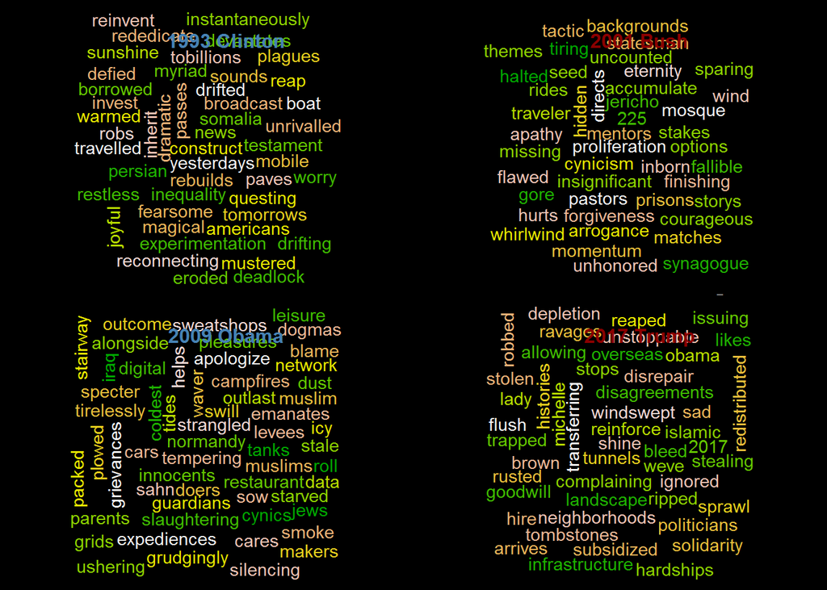

```r
#===============wordcloud by unique words for each speech============

set.seed(123)
par(family = "myfont", bg = "black", mfrow = c(2, 2))
our_inaugs <- c("1993-Clinton", "2001-Bush", "2009-Obama", "2017-Trump")
cols <- c("steelblue", "darkred", "steelblue", "darkred")
for(i in 1:length(our_inaugs)){
   newwords <- words %>%
      filter(total_count == count) %>%
      filter(inauguration == our_inaugs[[i]]) %$%
      wordcloud(words = .$word,
                colors = terrain.colors(15), random.color = TRUE, scale = c(1.1, 0.9))
   title(main = gsub("-", " ", our_inaugs[[i]]), col.main = cols[i])
}

grid.text(0.5, 0.53, label = "Unique words in inauguration speeches of recent in-coming US Presidents",
          gp = gpar(col = "grey90", fontfamily = "myfont", fontface = "bold", cex = 1.5))
```

```r
#=================wordcloud by tf-idf=================

for(i in 1:length(inaugs)){

   the_party <- presidents[presidents$inauguration == inaugs[[i]], "party"]

   # create palette of colours, suitable for the particular party
   palfun <- colorRampPalette(c("white", parties[the_party]))

   the_data <- subset(words, inauguration == inaugs[[i]]) %>%
      arrange(desc(tf_idf)) %>%
      slice(1:80) %>%
      arrange(tf_idf) %>%
      mutate(fading_colour = palfun(80))

   png(paste0(inaugs[[i]], ".png"), 1200, 1200, res = 100)
   showtext.opts(dpi = 100)
   par(family = "myfont")
   wordcloud(the_data$word,
             freq = the_data$tf_idf * max(the_data$tf_idf)* 50,
             colors = the_data$fading_colour,
             # uncomment the next line to put all words on the same scale, which makes many
             # individual wordclouds extremely small:
             # scale = c(6 * max(the_data$tf_idf) / max(words$tf_idf), 0.5),
             random.order = FALSE, random.color = FALSE, rot.per = 0)
   title(main = inaugs[[i]])
   grid.text(0.5, 0.05, label = "Most distinctive words used in US Presidential inauguration speeches",
             gp = gpar(fontfamily = "myfont", color = "grey50"))
   dev.off()
}

# tie the PNG frames together into a single animated GIF:
system('magick -loop 0 -delay 200 *.png "distinctive-presid-words.gif"')
```